# Song Lyrics Analysis

[figure not shown]

#### This report is a song lyrics analysis on word performance

#### The raw dataset: lyrics is a filtered corpus of 100,000+ song lyrics from MetroLyrics. You can find the complete 380,000+ song lyrics data on Kaggle.

This report may require the latest R version to view:

```r
print(R.version)
```

```
##                _
## platform       x86_64-apple-darwin15.6.0
## arch           x86_64
## os             darwin15.6.0
## system         x86_64, darwin15.6.0
## status
## major          3
## minor          6.1
## year           2019
## month          07
## day            05
## svn rev        76782
## language       R
## version.string R version 3.6.1 (2019-07-05)
## nickname       Action of the Toes
```

To start, I process the raw textual data ‘lyrics.csv’ by tokenizing, removing stopwords, and creating a tidy version of text.

When hear a song, the melody is always the first impression we have on it. For different genres of songs, the melodies seem to be quite distinct. While I’m curious about words variability of lyrics. Is the lyrics as changebale as melody, or on the opposite, immutable at core significant level?

I try to answer this question in general and in timeline from the given collection of song lyrics.

#### In general

```
## # A tibble: 30 x 2
##    word       n
##    <chr>  <int>
##  1 love  194052
##  2 time  113002
##  3 youre 100670
##  4 baby   77625
##  5 ill    71915
##  6 day    65576
##  7 life   62797
##  8 heart  58852
##  9 ive    57284
## 10 night  55015
## # … with 20 more rows
```

In total without any filtering, I can see from above table that ‘love’, ‘time’, ‘youre’, ‘baby’, and ‘ill’ are top 5 words to be mentioned in lyrics. And I visualize the result with word cloud.

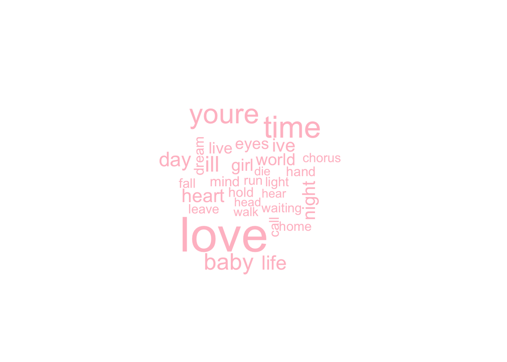

Then I filter dataset into different genres, and select the 4 largest genre groups to do analysis.

```
## # A tibble: 4 x 2
##   genre         n
##   <chr>     <int>
## 1 Rock    4130546
## 2 Hip-Hop 1738291
## 3 Pop     1403249
## 4 Metal    831134
```

The 4 largest genre groups of the dataset are Rock, Hip-Hop, Pop, Metal.

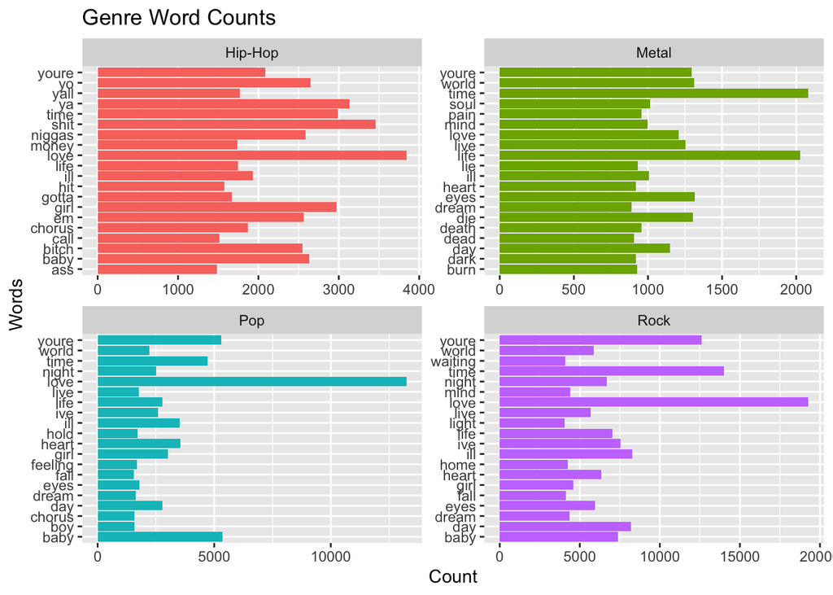

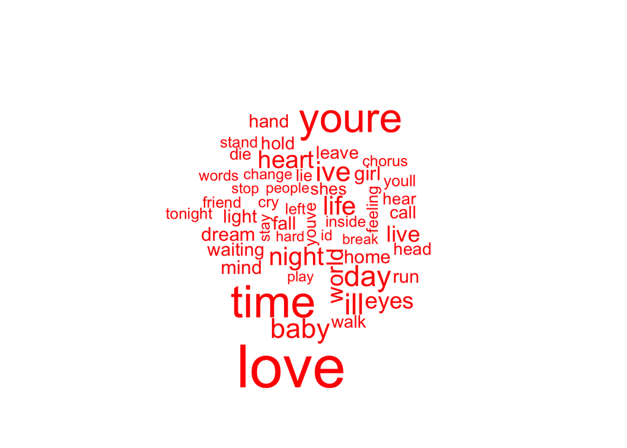

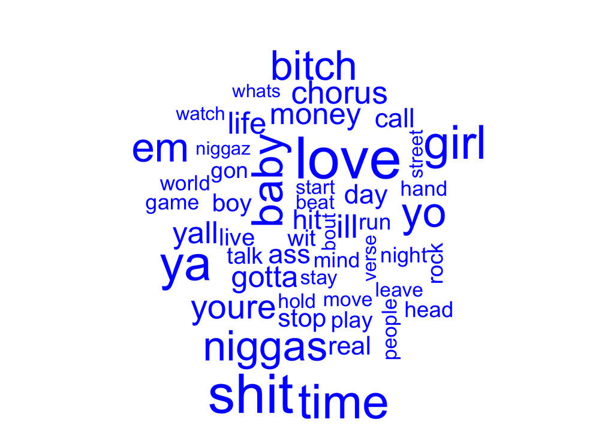

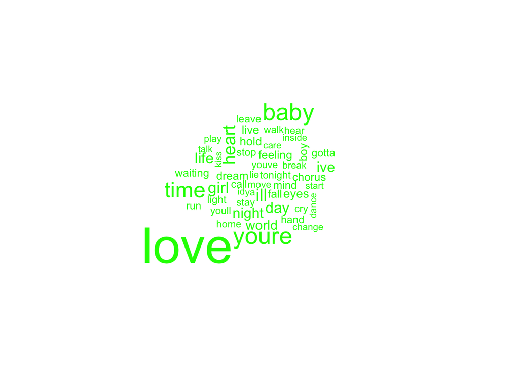

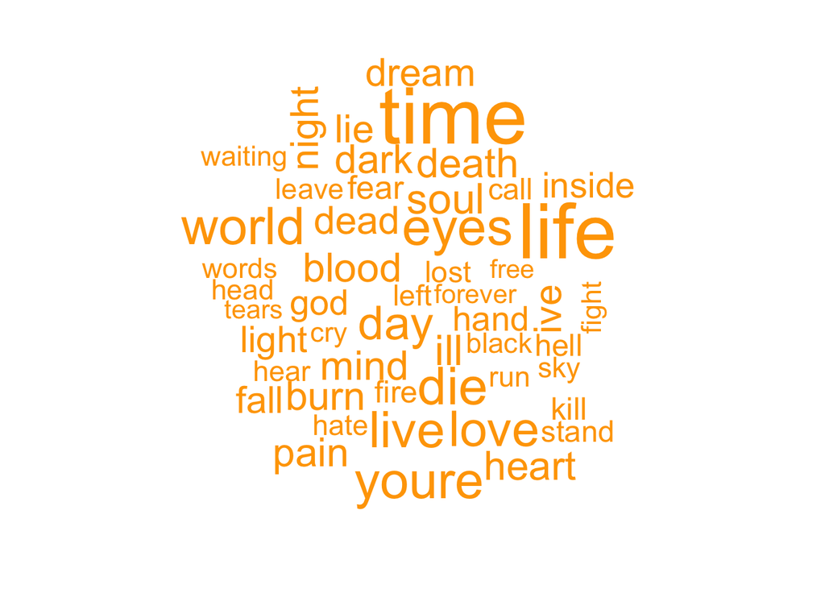

For Hip-Hop, ‘love’, ‘shit’, ‘ya’, ‘yo’, ‘girl’, ‘baby’, ‘bitch’, etc, are the most populor collection of words. Modal particles take an part that cannot be overlooked and indicate a strong emotional expression.

For Metal, ‘life’, ‘time’, ‘eyes’, ‘die’, ‘live’, ‘love’, etc, are the most populor collection of words. These words relate to a subculture to vent about society and social evils.

For Pop, ‘love’, ‘baby’, ‘time’, ‘girl’, ‘heart’, etc, are the most popular collection of words. Pop music is always about love story, especially heartbreak, and partying.

To summarize, these four genres all have high frequencies for ‘youre’, which means they use the second person to sing, and this allows writer to submerge the reader into the narrative completely. Besides, ‘love’ and ‘life’ both perform high frequencies in each subset, and this agrees with word performance in general; I conjecture that regardless of how wonderful or disappointed the love or life is, people always take care of the theme because lyrics draws similar moments and feelings everyone resonants with.

#### In timeline

```r
lyrics_data %>%
  count(year)
```

```
## # A tibble: 50 x 2
##     year     n
##    <dbl> <int>
##  1   112   172
##  2   702    82
##  3  1968    40
##  4  1970  6316
##  5  1971  7535
##  6  1972  7443
##  7  1973 10851
##  8  1974  8832
##  9  1975  5029
## 10  1976  2982
## # … with 40 more rows
```

Since there are 48 years except the two earliest, I divide the dataset into three time stages. the early stage is before 1985, the middle stage is between 1985 and 2000, the late stage is after 2000.

```
## # A tibble: 11 x 11
##    genre anger anticipation disgust  fear   joy negative positive sadness
##    <chr> <int>        <int>   <int> <int> <int>    <int>    <int>   <int>
##  1 Coun…   171          282     160   210   300      403      500     322
##  2 Elec…    67          118      49    75   181      195      240     122
##  3 Folk     40           73      17    33    96       89      151      48
##  4 Hip-…     9           20       7     6    34       13       61       7
##  5 Jazz    338          774     265   418  1372      753     1853     511
##  6 Metal    71           36      50    84    34      118       58      76
##  7 Not …   482          416     290   607   659      925     1138     484
##  8 Other    77          144      72    84   225      123      270     105
##  9 Pop    1180         1750     821  1360  3044     2472     4104    1640
## 10 R&B     285          499     271   354   927      592     1321     411
## 11 Rock   4692         6001    3864  5800  7561    10192    11891    5878
## # … with 2 more variables: surprise <int>, trust <int>
```

In the above table, I use ‘nrc’ to do a sentiment analysis. ‘nrc’ lexicon categorizes words in a binary fashion into categories of positive, negative, anger, anticipation, disgust, fear, joy, sadness, surprise, and trust. By looking at the counts under each columns in the table, it’s easy to figure out what kind of emotions is most widely used in lyrics creation.

```
## positive
##        8
```

For example, Country music tend to use positive words in lyrics before year 1985.

```
## # A tibble: 11 x 11
##    genre anger anticipation disgust  fear   joy negative positive sadness
##    <chr> <int>        <int>   <int> <int> <int>    <int>    <int>   <int>
##  1 Coun…   911         1203     846  1192  1573     2322     2516    1589
##  2 Elec…   200          347     161   263   345      445      636     256
##  3 Folk    159          151     132   205   194      315      315     194
##  4 Hip-…  3343         2371    2364  2728  2767     5709     5399    2338
##  5 Jazz    553          985     541   714  1706     1239     2362     897
##  6 Metal  1938         1657    1447  2627  1491     3862     2975    2451
##  7 Not …   737         1106     522   923  1433     1500     2202     854
##  8 Other    12           32       5     9    35       18       52      37
##  9 Pop    2121         3364    1516  2567  5510     4192     7560    2916
## 10 R&B     827         1072     722   973  2317     1692     3103    1151
## 11 Rock  13528        15640   10462 16440 20154    28544    31891   17588
## # … with 2 more variables: surprise <int>, trust <int>
```

```
## positive
##        8
```

The most frequently used words are still positive between year 1968 and 2000.

```
## # A tibble: 12 x 11
##    genre  anger anticipation disgust   fear    joy negative positive
##    <chr>  <int>        <int>   <int>  <int>  <int>    <int>    <int>
##  1 Coun…  25959        37591   20956  31203  52169    56506    76067
##  2 Elec…  12319        14531    8598  14660  19890    25257    30863
##  3 Folk    2238         3073    1766   2752   3592     5044     6041
##  4 Hip-… 141128        96061  101702 127414 102690   240195   205238
##  5 Indie   5123         6558    4072   6540   7969    11371    12333
##  6 Jazz   10683        18739    8562  12760  30934    22692    42431
##  7 Metal  84958        68550   62823 111717  58131   175786   114895
##  8 Not …  14418        19148   11087  18430  26466    31084    40647
##  9 Other    999          786     754    934   1191     1769     1775
## 10 Pop    89673       112261   69419 103616 176797   180343   254940
## 11 R&B     8587        10751    6657  10364  18907    17298    26462
## 12 Rock  273672       325615  210756 338598 385875   583015   616510
## # … with 3 more variables: sadness <int>, surprise <int>, trust <int>
```

```
## positive
##        8
```

Country music keeps using postive words until year 2016.

I make an assumption here that the collection of words faintly change through time based on sentiment. To verify my assumption, I initially visualize the word cloud for each stage.

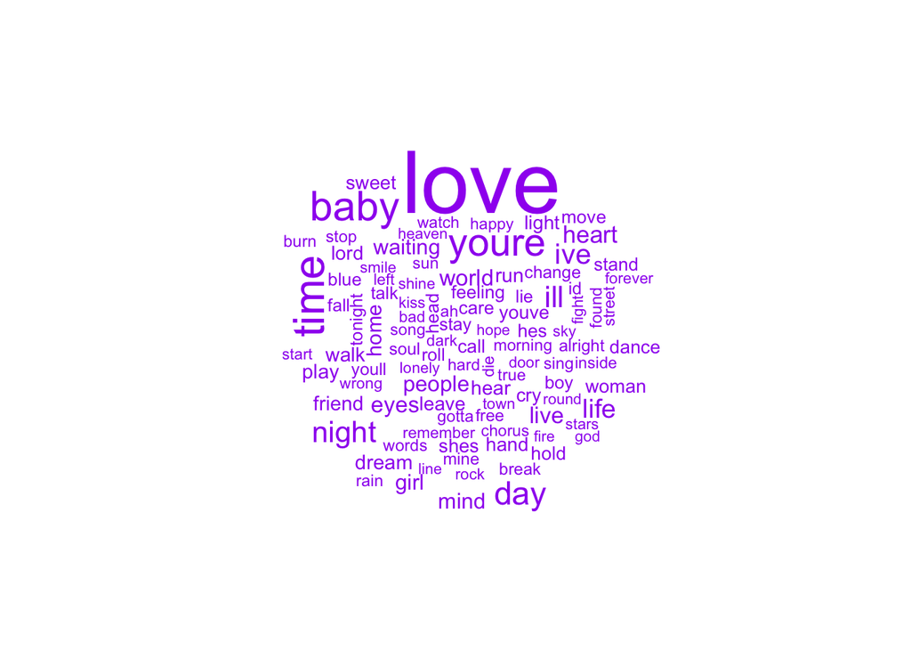

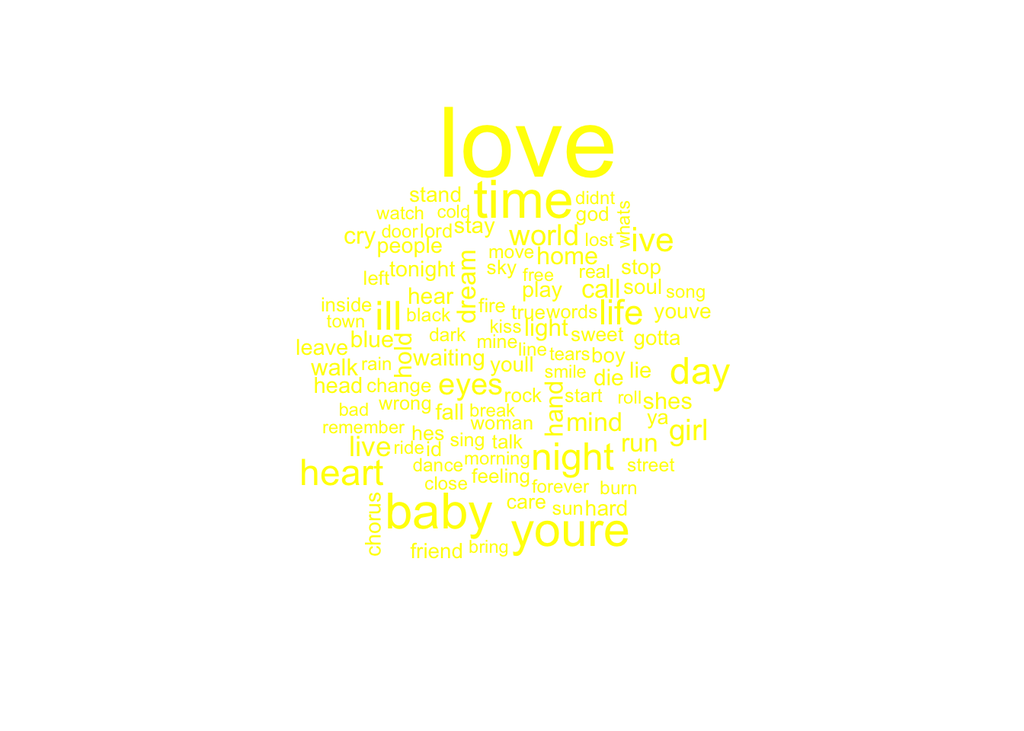

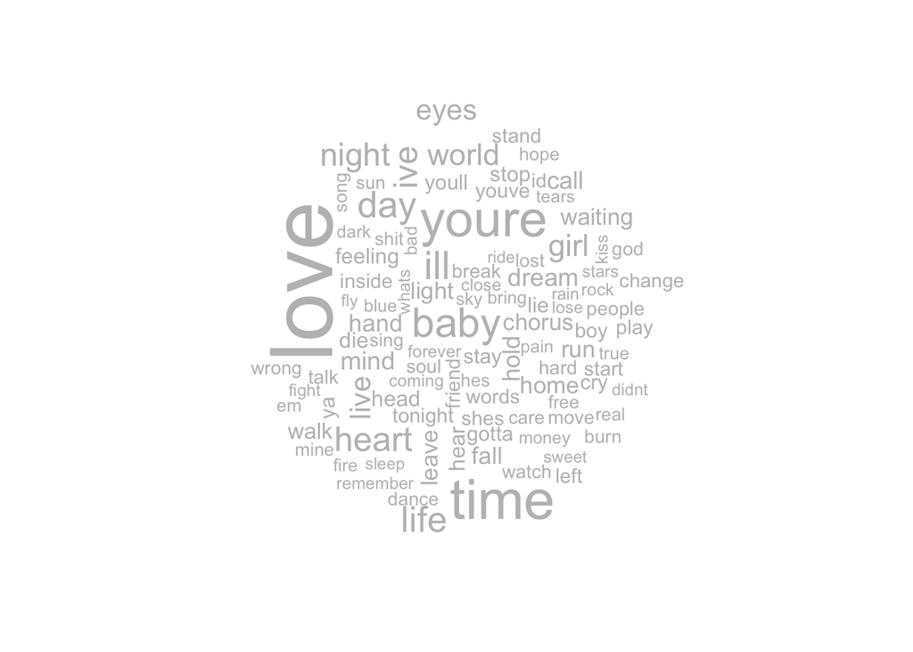

It seems not bad from the word cloud. However, a more scientific topics modeling is better for this situation.

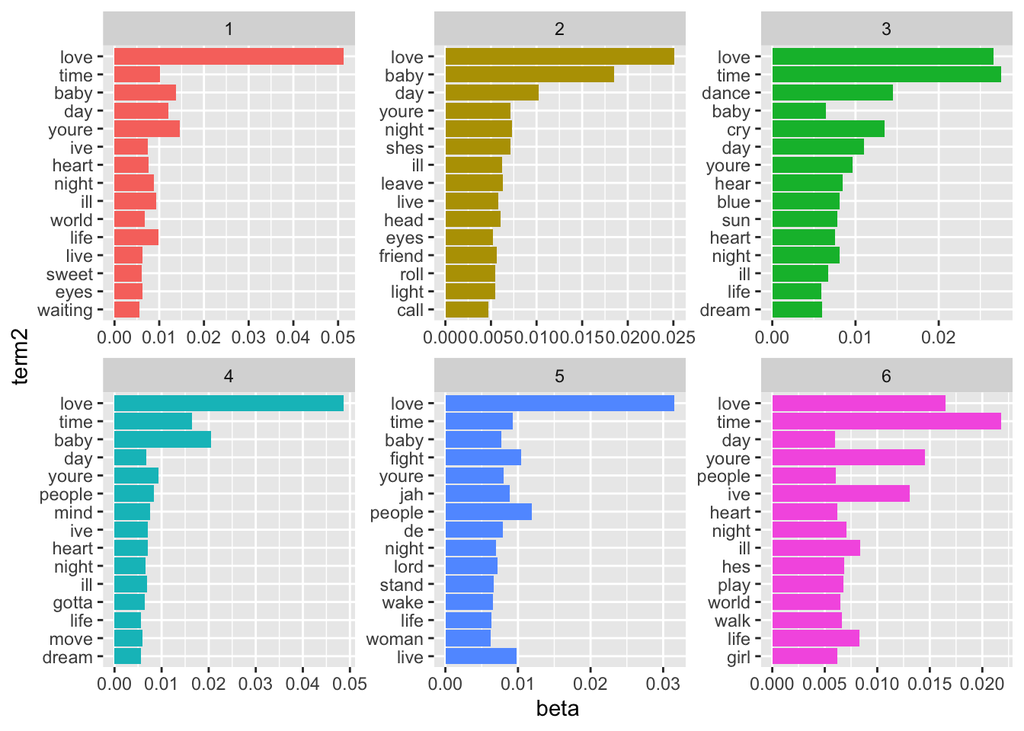

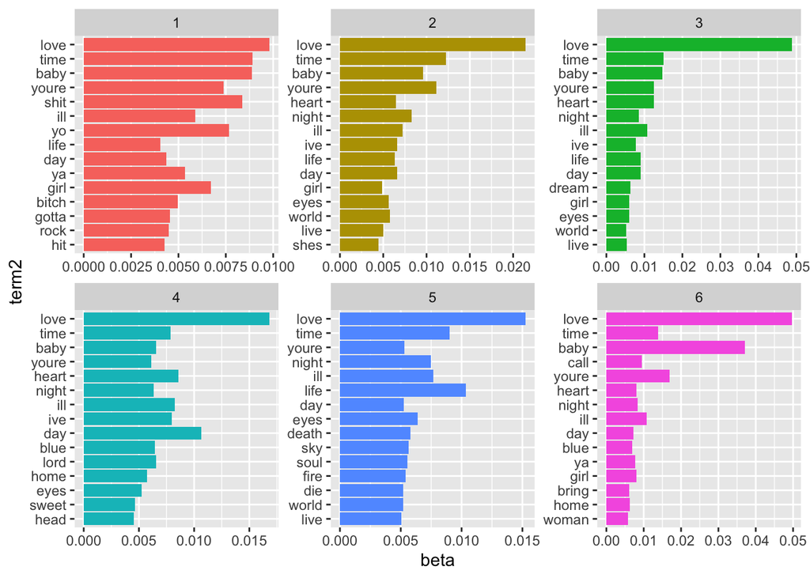

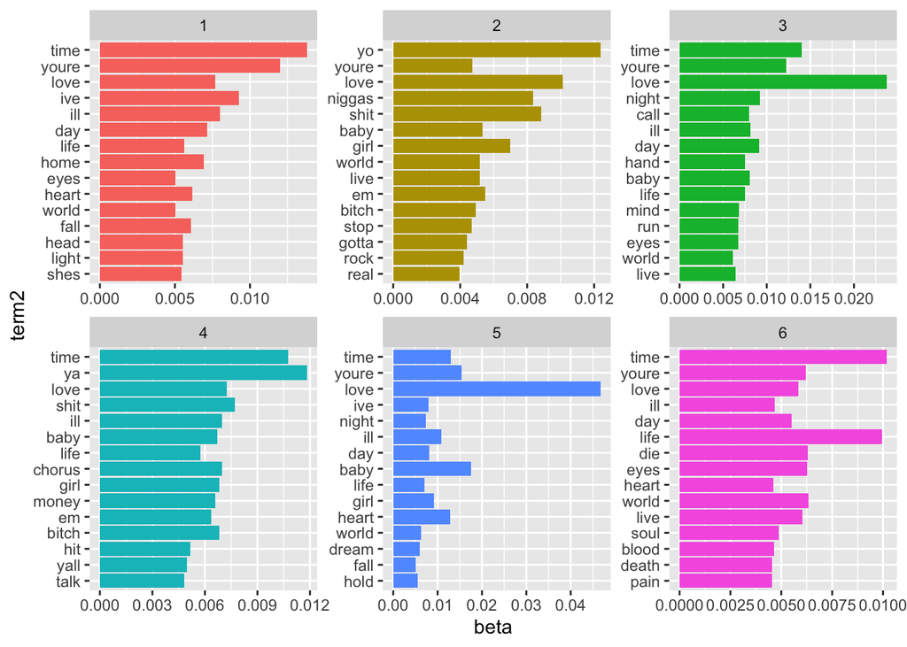

Latent Dirichlet allocation (LDA) is a particularly popular method for fitting a topic model. It treats each document as a mixture of topics, and each topic as a mixture of words. This allows documents to “overlap” each other in terms of content, rather than being separated into discrete groups, in a way that mirrors typical use of natural language.

Looking at the topics modeling above, I find that the topics for early stage and middle stage are distributed very similar, while for late stage, the ranking of top words change, even though the collection remains the same; it seems like love story is definitely the most important topic before year 2000, compared to recent years that time topic weight more and modal particles add.

#### Conclusion

By analyzing the song lyrics data on word performance, I come up with the following results.

- Love and time stories are topics with the highest frequencies expected to see in lyrics, regardless of different genres.
- Collection of words in song lyrics do not change obviously in various time stages, which indicates similar emotional expression.

[figure not shown]

#### References

https://www.liveabout.com/what-is-heavy-metal-p2-2456255

https://www.quora.com/What-are-some-common-themes-in-pop-music

https://www.tidytextmining.com/sentiment.html